# HW5

kliu321

2019-09-29

This document is generated using Rmarkdown with python code inside. Rmarkdown was used because of its capability of generating self-contained html, which is convinient when images needs to be embedded along with codes.

# 1. Question 1

[figure not shown]

## 1(a)

The feasible region is highlighted in the black shaded region

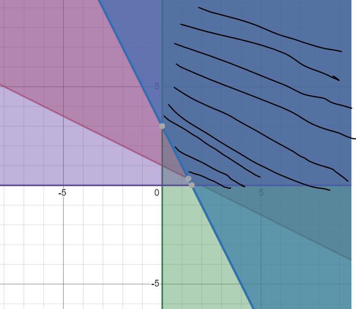

## 1(c)

First, import library

```python
import pandas as pd
import numpy as np
import cvxpy as cp
```

Solve problem using CVXPY

```python
x1 = cp.Variable()
x2 = cp.Variable()

objective = cp.Minimize(3*x1 + x2)
constraints = [x1+2*x2>=2, 2*x1+x2>=3, x1>=0, x2>=0]

prob = cp.Problem (objective, constraints)

try:
  prob.solve()
  print("status:", prob.status)
  print("optimal objective value", prob.value)
  print(f"Optimial solution: x1 = {x1.value}, x2 = {x2.value}")


except:
  print ("something was wrong with the optimizer")
```

```
## 3.0
## status: optimal
## optimal objective value 3.0
## Optimial solution: x1 = 7.861097117009218e-23, x2 = 3.0
```

# 2. Question 2

[figure not shown]

## 2(a)

$min \sum^{m}_{i=1} \sum^{n}_{j=1} c_{ij}x_{ij}$

subject to: $\sum^{m}_{i=1} x_{ij}>= d$, j = 1, …, n

$\sum^{n}_{j=1} x_{ij}<= s_i$, i = 1, …, m

$x_{ij} >=0$, i = 1,…, m and j = 1,…,n

where: $s_i$ is the amount of supply from supplier i

$d_j$ is the amount of demand for customer j

$x_{ij}$ is the amount of product transported from supplier i to customer j

$c_{ij}$ is the cost to transport a unit of product from supplier i to customer j

## 2(b)

```python
m = 4
n = 3

# create the supply matrix, should be a vertical matrix
supply = np.matrix([[10], [25], [18], [15]])

# create the demand matrix, should be a vertical matrix
demand = np.matrix([[15], [20], [16]])

#Create the cost matrix, should be a m X n matrix. For the node without a path define, set the cost to be a very high number (9999)
cost = np.matrix([[2,3,9999], [4,9999,5],[2,3,4], [5,9999,3]])

# syntax for creating a matrix as variable
x = cp.Variable([4,3])

# use elementwise multiplciation instead of dot product.
objective = cp.Minimize(cp.sum(cp.multiply(x,cost)))


constraints = [cp.sum(x, axis = 0, keepdims = True).T >= demand, cp.sum(x, axis = 1, keepdims = True) <= supply, x >= 0 ]

prob = cp.Problem(objective, constraints)
try:
  prob.solve()
  print ("Solver Status:", prob.status)
  print(f"optimal objective value: {np.round(prob.value,4)}" )
  print(f"Optimial solution: \n x = {np.round(x.value,4)}")

except:
  print ("something was wrong with the optimizer")
```

```
## 154.0
## Solver Status: optimal
## optimal objective value: 154.0
## Optimial solution:
##  x = [[ 2.  8. -0.]
##  [ 7.  0.  1.]
##  [ 6. 12. -0.]
##  [ 0.  0. 15.]]
```

## 2(c)

When the supply has to match demand exactly, I found that there is no change in the optimal solution.

```python
m = 4
n = 3

# create the supply matrix, should be a vertical matrix
supply = np.matrix([[10], [25], [18], [15]])

# create the demand matrix, should be a vertical matrix
demand = np.matrix([[15], [20], [16]])

#Create the cost matrix, should be a m X n matrix. For the node without a path define, set the cost to be a very high number (9999)
cost = np.matrix([[2,3,9999], [4,9999,5],[2,3,4], [5,9999,3]])

# syntax for creating a matrix as variable
x = cp.Variable([4,3])

# use elementwise multiplciation instead of dot product.
objective = cp.Minimize(cp.sum(cp.multiply(x,cost)))


constraints = [cp.sum(x, axis = 0, keepdims = True).T == demand, cp.sum(x, axis = 1, keepdims = True) <= supply, x >= 0 ]

prob = cp.Problem(objective, constraints)
try:
  prob.solve()
  print ("Solver Status:", prob.status)
  print(f"optimal objective value: {np.round(prob.value,4)}" )
  print(f"Optimial solution: \n x = {np.round(x.value,4)}")

except:
  print ("something was wrong with the optimizer")
```

```
## 154.0
## Solver Status: optimal
## optimal objective value: 154.0
## Optimial solution:
##  x = [[ 2.  8. -0.]
##  [ 7.  0.  1.]
##  [ 6. 12. -0.]
##  [ 0.  0. 15.]]
```

# 3. Question 3

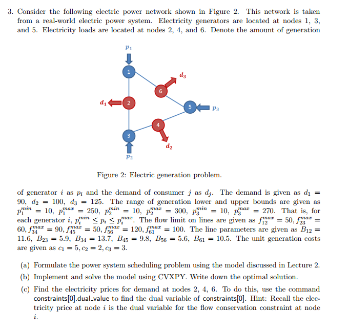

## 3(a)

Objective: Minimize $\sum^{G}_{i=1} c_ip_i$

Subject to: Flow Conservation: $\sum_{j \in O(i)} f_{ij}$ - $\sum_{j \in I(i)} = p_i$ for $i \in G$ (for generator node)

$\sum_{j \in O(i)} f_{ij}$ - $\sum_{j \in I(i)} = -d_i$ for $i \in D$ (for consumer node)

$\sum_{j \in O(i)} f_{ij}$ - $\sum_{j \in I(i)} = 0$ for $i \in N/(G \cup D)$ (for node other than generators or consumer nodes, which does not exists in this problem)

Flow Limit Constraint: $-F_{ij} <= f_{ij} <= F_{ij}$

Generator Physical limit constraints: $p^m_{i} <= p_i <= p^M_{i}$ for all $i \in G$

where: The amount of generation of generator i as $p_i$ and the demand of consumer j as $d_j$.

## 3(b)

```python
# use simple math instead of linear algebra and matrix operation due to the complexity of the problem

# define the cost for each generator
c1 = 5
c2 = 2
c3 = 3

# define the demand for each consumer
d1 = 90
d2 = 100
d3 = 125

# define the minimal and maximum capacity of each generator
(p1_min, p2_min, p3_min) = (10,10,10)
(p1_max,p2_max,p3_max) = (250,300,270)

#define flow limit constraint
F12 = 50
F23 = 60
F34 = 90
F45 = 50
F56 = 120
F61 = 100

#define line parameter
B12 = 11.6
B23 = 5.9
B34 = 13.7
B45 = 9.8
B56 = 5.6
B61 = 10.5


# set up decision variable using CVXPY

# set up decision variables for amount of power generator for each generator
p1 = cp.Variable()
p2 = cp.Variable()
p3 = cp.Variable()

# set up decision variables for flow between nodes. Flow can be negative
f12 = cp.Variable()
f23 = cp.Variable()
f34 = cp.Variable()
f45 = cp.Variable()
f56 = cp.Variable()
f61 = cp.Variable()

# set up decision variables for electrical potential in each node (think of it as voltage).
T1 = cp.Variable()
T2 = cp.Variable()
T3 = cp.Variable()
T4 = cp.Variable()
T5 = cp.Variable()
T6 = cp.Variable()

#objective. The objective is to minize cost
objective = cp.Minimize(p1*c1+p2*c2+p3*c3)

#constraint

# the constraints follows the formulated listed above:
#Outflow - Inflow = P
#Outflow - Inflow = -d

#f12 for node 1 means outflow, while f12 for node 2 means inflow


#constraint for generation node
constraint1 = [(f12-f61) == p1, (-f23 + f34) == p2, (-f45 + f56) == p3]

#constraint for consumer node
constraint2 = [(f23-f12) == -d1, (f45-f34) == -d2  , (f61-f56) == -d3 ]

#constraint for upper bound and lower bound of generation limit
constraint3 = [p1 >= p1_min, p1 <= p1_max, p2 >= p2_min, p2 <= p2_max, p3 >= p3_min, p3 <= p3_max]

#Flow limit constraint
constraint4 = [f12 <= F12, f12 >= -F12, f23 <= F23, f23 >= -F23,  f34 <= F34, f34 >= -F34, f45 <= F45, f45 >= -F45,  f56 <= F56, f56 >= -F56, f61 <= F61, f61 >= -F61]

#branch flow and nodal potential constraint
#Always assume the generator node has higher potential then the consumer node
constraint5 = [f12 == B12*(T1-T2), f23 == B23 * (T2-T3), f34 == B34 * (T3-T4), f45 == B45*(T4-T5), f56 == B56 * (T5-T6), f61 == B61 * (T6-T1)]


all_constraints = constraint1 + constraint2 + constraint3 + constraint4 + constraint5


prob = cp.Problem(objective, all_constraints)

try:
  prob.solve()
  print ("Solver Status:", prob.status)
  print (f"p1 = {p1.value}, p2 = {p2.value}, p3 = {p3.value}")
  print (f"f12 = {f12.value}, f23 = {f23.value}, f34 = {f34.value}, f45 = {f45.value}, f56 = {f56.value}, f61 = {f61.value}")
  print (f"At optimal solution, the objective function has a value of {prob.value}")

except:
  print ("Something was wrong during optimization process")
```

```
## 992.043652666871
## Solver Status: optimal
## p1 = 78.52182633343551, p2 = 110.0, p3 = 126.47817366656449
## f12 = 30.0, f23 = -60.0, f34 = 50.0, f45 = -50.0, f56 = 76.47817366656449, f61 = -48.52182633343551
## At optimal solution, the objective function has a value of 992.043652666871
```

## 3(c)

```python
print(f"price at node 2 = {np.round(all_constraints[3].dual_value,4)}, price at node 4 = {np.round(all_constraints[4].dual_value,4)}, price at node 6 = {np.round(all_constraints[5].dual_value,4)}")
```

```
## price at node 2 = 5.6297, price at node 4 = 2.5332, price at node 6 = 4.3043
```